# finalproject

Vaccination Effect on Deaths Caused by COVID-19 Globally

Joanne Drake, ID 920232835

Date: 03/07/2022

Abstract:

Vaccinations have been touted as one of the key ways to stop the spread of COVID-19 and decrease the chances of hospitalizations and deaths. Through the use of data and plots, we hope to show the relationship between vaccinations and the occurance of death. We speculate that with the introduction of vaccinations, and the increasing number of people being vaccinated has helped to decreased the occurance of death throughout populations.

Introduction:

In late 2019, a group of patients in Wuhan Hubei Providence of China experience shortness of breath and fever that would be reported as cases of pneumonia of unknown etiology to the World Health Organization China Country Office. With further investigation, Chinese authorities identified a novel coronavirus as the agent that caused the outbreak. Within days, reports of import of the novel coronavirus were confirmed in other countries and the Center for Disease Control and Prevention began screeninging flights from Wuhan China to major airlines and found that the virus was spreading worldwide and the CDC transitioned to "a Center-led Incident Management Structure to an Agency-wide Structure and ...[activated]... its Emergency Response System"(CDC,2022). From this countries globally took actions to prevent the spread of COVID-19 including but not limited to wearing masks, testing, enacting quarantines, limiting travel and eventually developing vaccines. Since the beginning, data has been collected regarding many facets of the virus including counts of cases, counts of deaths, policy enactments, information on vaccinations. However, it is important to note that the data depends heavily on reporting and not all countries have equal resources and access to the same level of healthcare everywhere. This potentially leaves holes in the information that we have relating to the world as a whole and we can suspect that we do not have a complete picture of everything and potentially do not have exact counts in terms of deaths and cases. Despite this, we try to utilize the information we do have access to to make decisions regarding the best actions we can do to stop the spread and lower probability of death. One of those actions that have been isolated as key to protecting populations from COVID-19 and reducing the chance of hospitalization and potentially death is vaccination. In December 2020, vaccinations started being approved for the public with the purpose of providing of immunity that would protect population from and decrease the severity of COVID-19. Which brings us to the goal of this project, to establish whether the introduction of vaccinations helped to decrease the possibility of death among the world population.

Background:

COVID-19 quickly became a source of concern as it quickly spread to new countries rapidly. In response, data has been collected and reported early on in the pandemic. The data has been tracking new cases, hospitalizations, new deaths, cumulative counts, policies implemented in response to the pandemic and many other feature. Since the focus of this project is the effect of vaccination on the potential outcome of death, we focus on those two aspects more closely. We utilized mainly the World Health Organization (WHO) COVID-19 data set as well has the WHO vaccine data set. The WHO COVID-19 Data set contains variables of data reported, country, country code, new cases, cumulative cases, new deaths and cumulative deaths. The WHO vaccination data set contains variables of country, country codes, date last reported, total vaccinations, total persons with plus 1 dose, total persons with plus 1 dose per 100, total fully vaccinated persons, total fully vaccinated persons per 100, first vaccine date, number (types) of vaccines, whcih vaccines available.

Descriptive Analysis:

After loading the WHO data set, we first attempt to perform some summary analysis. In doing so we saw that there are 190074 observations but upon closer inspection we noted that this is due to multiple entries per country based on date of reporting. It is important to note that reporting is not necessary done equality between countries and that some countries report more than others. The other issue that occurs with a data set based daily entries of reporting is that the resulting mean of the summary statistics may not be as reliable, especially considering the variables of cumulative deaths and cuulative cases which could potentially skew the data by recounting counts multiple times.

Because a variable of interest is vaccination, we wanted to merge WHO COVID data set with that of the WHO vaccination data set via an inner join by country and well as merging in population data in order to focus on ratios of people vaccinated and ratios of deaths in relation to population. When doing the inner join of the different data sets, found that the variable I chose to join by could drastically affect the number of observations left in my data set. I tried multiple joins and chose the join that lost the least amount of data. The cause of data loss typically was related to a mismatch of entry formats. I attempted to use functions that were intended to standardize, but typically resulted in computer crashes. Because my intention was to filter the data anyway, I decided to accept the loss since I was still left with over 166000 observations.

We wanted to further observe the data via visualization and decided to graph new deaths in relation to the date reported and grouped by country to follow the trends of the new deaths by country. However this resulted in an extremely crowded line graph with a lot going on. This is due partially to the long range of dates that span from January 2020 to current day. That means we are displaying over 2 years worth of data, so we would need to focus on a smaller subset of dates for the graph to look visually appealing. The other thought that came to mind was that there are 207 countries being displayed and this also probably contributes to the over crowding of the graph. I decided to limit the dates from September 2020 to September 2021, that way the data would represent a time before vaccines were administered and time after. This helped reduce the crowding of the line graph. Just to play around I also wanted to see how the graph would change had I limited the data to a specific region, It did but the graph was still a bit difficult to distinguish.

Inferential Analysis:

Because I do not feel the strongest skill wise in creating models, I opted to have r create one for me using the step function. I note here that the model took awhile to be created and resulted in many warning signs. I acknowledge that this is probably due to the data requiring more cleaning and preprocessing. I believe that vaccinations should have a relation to cumulative deaths in that they reduce the chance of death, however the model created via the step function does not seem to include any of the variabes pertaining to vaccination. This is probably where expliciting stating a model would come in handy I suppose.

The resulting model based on stepwise selection:

Cumulative deaths = Country (as.factor) + New_deaths + Country(as.factor):New_deaths

Sensitivity Analysis:

From the Sensitivity analysis plots, we find that the model does not follow assumption of linearity or equal variance. The plot points are heavily populated to the left and then spread out on the right. In terms of the normal qq plot, the plot does not follow the diagonal line that signifies normality. It does seem to follow a line, but not the straight diagonal that one would expect if followed the normality assumption. In terms of the residual leverage plot, we do not have any extreme values past the cook's distance line, but once again plots are heavily skewed to the left.

Discussion:

Based on the model created by r, the model suggests that vaccinations are not related to the cumulative deaths. I still believe that vaccinations do have an affect on the number of deaths, and that vaccinations have helped save people from getting COVID, from being hospitalized from COVID, and from dying from COVID. I beleive that I may have messed up in the preprocessing of the data, or that the numbers are confused as some variables are counts and some are ratios and more standardization may have been necessary to achieve a better results. Another alternative would have been building my own model and seeing what those results may have said. Regardless, I will conclude based off the results I did get. That being that the main factors affecting cumulative deaths included Country and new deaths and the interaction between the two. This result is possibly related to the fact that some countries had more cases that lead to more deaths than others that contributed more to the cumulative death conts than others. There are many factors that could have played a role in why certain countries had more deaths than other. Some reasonings may include higher populations and thus higher probabilities of people getting COVID. Higher populations may mean more proximity, there keeping a 6 feet distance is less possible depending on the population density. Different countries enacted different policies in response to COVID. Some countries had less access to testing to detect COVID sooner and therefore more likely to die from COVID due to not detecting it soon enough. Some countries had less access to heathcare and maybe did not have access to vaccinations. Which is why I haven't let go of my initial hypothesis, lack of vaccination may still be embedded in why Country was a variable related to cumlative deaths. It is important to keep in mind that COVID-19 is still present and we are still collecting data and still trying to understand COVID-19 and findings are still possible as we try to unfold and discover what we can about this pandemic.

Acknowledments:

Thank you to Professor Chen for making the most of this winter quarter, I know it was not ideal.

Thank you to Xiawei for making the most of discussions as well as for your kind words. I appreciated your email and it did help.

Thank you to Sam Kevy for coming to discussion so there was someone to discuss with.

References:

Centers for Disease Control and Prevention. (2022, January 1).CDC Museum Covid-19 Timeline. CDC. 'https://www.cdc.gov/museum/timeline/covid19.html' [Online Resource]

Hannah Ritchie, Edouard Mathieu, Lucas Rodés-Guirao, Cameron Appel, Charlie Giattino, Esteban Ortiz-Ospina, Joe Hasell, Bobbie Macdonald, Diana Beltekian and Max Roser (2020) - "Coronavirus Pandemic (COVID-19)". Published online at OurWorldInData.org. Retrieved from: 'https://ourworldindata.org/coronavirus' [Online Resource]

World Health Organization (WHO): https://covid19.who.int/who-data/vaccination-data.csv

https://www.google.com/covid19/mobility/

https://cran.r-project.org/web/packages/countrycode/countrycode.pdf

https://cran.r-project.org/web/packages/maps/maps.pdf

```r
library(tidyverse)
library(gridExtra)
library(scales)
library(lubridate)
library(ggplot2)
library(maps)
install.packages("countrycode")
library(countrycode)
```

```r
covid <- read.csv("https://covid19.who.int/WHO-COVID-19-global-data.csv")
#write.csv(covid,file="../Data/WHO-Covid-19-backup.csv")
#head(covid)
#length(unique(covid$Country))
covidtot <- covid %>% select(Date_reported, Country_code, Country, WHO_region, New_deaths, Cumulative_deaths)
length(unique(covidtot$Country))
head(covidtot)

vaccine <- read.csv("vaccination-data.csv")
head(vaccine)
length(vaccine$COUNTRY)
range(vaccine$FIRST_VACCINE_DATE)

pop <- read.csv("population.csv")
#head(pop)
#length(pop$Country.Name)
pop2020 <- pop %>% select(Country.Name, Country.Code, X2020)
head(pop2020)
length((pop$X2020))
```

237

A data.frame: 6 × 6

|  | Date_reported <chr> | Country_code <chr> | Country <chr> | WHO_region <chr> | New_deaths <int> | Cumulative_deaths <int> |
| --- | --- | --- | --- | --- | --- | --- |
| 1 | 2020-01-03 | AF | Afghanistan | EMRO | 0 | 0 |
| 2 | 2020-01-04 | AF | Afghanistan | EMRO | 0 | 0 |
| 3 | 2020-01-05 | AF | Afghanistan | EMRO | 0 | 0 |
| 4 | 2020-01-06 | AF | Afghanistan | EMRO | 0 | 0 |
| 5 | 2020-01-07 | AF | Afghanistan | EMRO | 0 | 0 |
| 6 | 2020-01-08 | AF | Afghanistan | EMRO | 0 | 0 |

A data.frame: 6 × 14

|  | COUNTRY <chr> | ISO3 <chr> | WHO_REGION <chr> | DATA_SOURCE <chr> | DATE_UPDATED <chr> | TOTAL_VACCINATIONS <dbl> | PERSONS_VACCINATED_1PLUS_DOSE <int> | TOTAL_VACCINATIONS_PER100 <dbl> | PERSONS_VACCINATED_1PLUS_DOSE_PER100 <dbl> | PERSONS_FULLY_VACCINATED <int> | PERSONS_FULLY_VACCINATED_PER100 <dbl> | VACCINES_USED <chr> | FIRST_VACCINE_DATE <chr> | NUMBER_VACCINES_TYPES_USED <int> |
| --- | --- | --- | --- | --- | --- | --- | --- | --- | --- | --- | --- | --- | --- | --- |
| 1 | Afghanistan | AFG | EMRO | REPORTING | 2022-02-14 | 5321308 | 4723416 | 13.669 | 12.134 | 4043580 | 10.387 | Beijing CNBG - BBIBP-CorV,Janssen - Ad26.COV 2-S,Pfizer BioNTech - Comirnaty,SII - Covishield | 2021-02-22 | 4 |
| 2 | Albania | ALB | EURO | REPORTING | 2022-02-06 | 2646554 | 1267908 | 92.000 | 44.551 | 1165189 | 40.942 | AstraZeneca - Vaxzevria,Gamaleya - Gam-Covid-Vac,Pfizer BioNTech - Comirnaty,SII - Covishield,Sinovac - CoronaVac | 2021-01-13 | 5 |
| 3 | Algeria | DZA | AFRO | REPORTING | 2022-02-08 | 13461201 | 7403900 | 30.698 | 16.884 | 6003539 | 13.691 | Beijing CNBG - BBIBP-CorV,Gamaleya - Gam-Covid-Vac,SII - Covishield,Sinovac - CoronaVac | 2021-01-30 | 4 |
| 4 | American Samoa | ASM | WPRO | REPORTING | 2022-01-28 | 82992 | 41820 | 150.356 | 75.765 | 36804 | 66.678 | Janssen - Ad26.COV 2-S,Moderna - Spikevax,Pfizer BioNTech - Comirnaty | 2020-12-21 | 3 |
| 5 | Andorra | AND | EURO | REPORTING | 2022-01-23 | 140193 | 57709 | 181.400 | 75.756 | 53104 | 69.711 | AstraZeneca - Vaxzevria,Moderna - Spikevax,Pfizer BioNTech - Comirnaty | 2021-01-20 | 3 |
| 6 | Angola | AGO | AFRO | REPORTING | 2022-02-09 | 15505389 | 10241793 | 47.177 | 31.162 | 5088239 | 15.482 | SII - Covishield | 2021-03-10 | 1 |

228

1. ''

2. '2021-10-18'

A data.frame: 6 × 3

|  | Country.Name <chr> | Country.Code <chr> | X2020 <dbl> |
| --- | --- | --- | --- |
| 1 | Aruba | ABW | 106766 |
| 2 | Africa Eastern and Southern | AFE | 677243299 |
| 3 | Afghanistan | AFG | 38928341 |
| 4 | Africa Western and Central | AFW | 458803476 |
| 5 | Angola | AGO | 32866268 |
| 6 | Albania | ALB | 2837743 |

266

```r
summary(covidtot)
```

```
 Date_reported      Country_code         Country           WHO_region
 Length:190074      Length:190074      Length:190074      Length:190074
 Class :character   Class :character   Class :character   Class :character
 Mode  :character   Mode  :character   Mode  :character   Mode  :character



   New_deaths      Cumulative_deaths
 Min.   : -60.00   Min.   :     0
 1st Qu.:   0.00   1st Qu.:     1
 Median :   0.00   Median :   128
 Mean   :  31.79   Mean   : 10880
 3rd Qu.:   6.00   3rd Qu.:  2445
 Max.   :8786.00   Max.   :960144
```

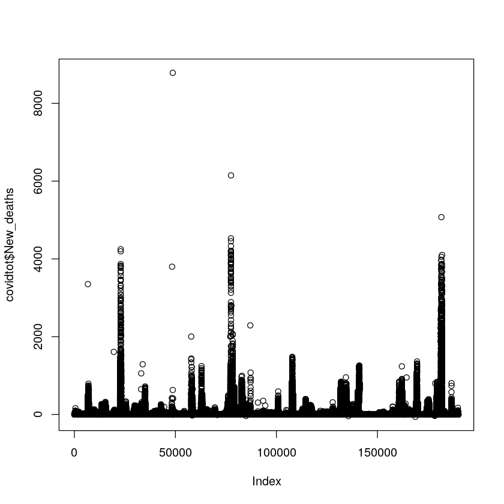

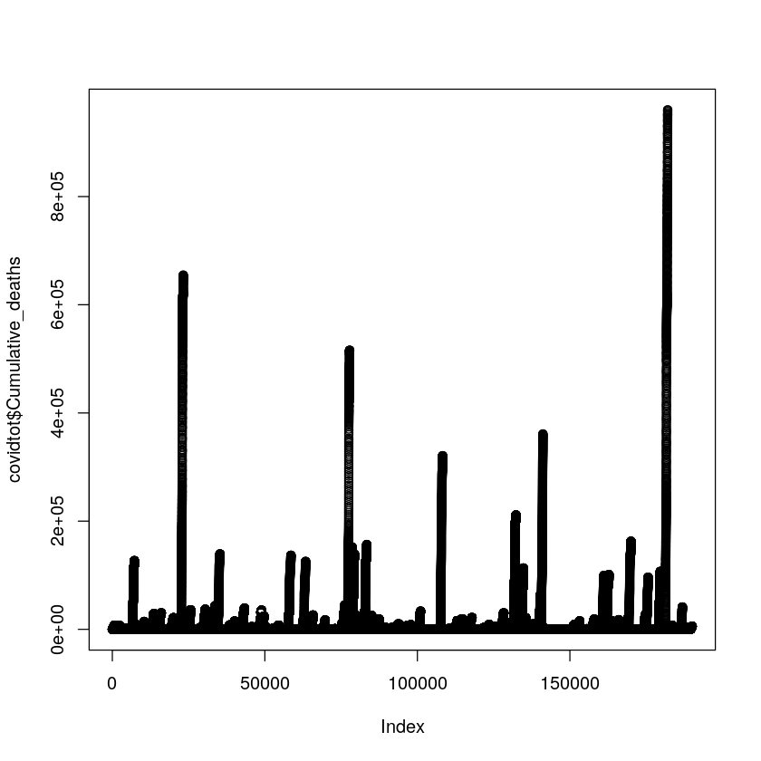

```r
plot(covidtot$New_deaths)
plot(covidtot$Cumulative_deaths)
```

```r
covvax <- inner_join(covidtot, vaccine, by = c("Country" = "COUNTRY", "WHO_region" = "WHO_REGION"))
covall <- inner_join(covvax, pop2020, by = c("ISO3" = "Country.Code"))
length(covall$Country)
head(covall)
```

166014

A data.frame: 6 × 20

|  | Date_reported <chr> | Country_code <chr> | Country <chr> | WHO_region <chr> | New_deaths <int> | Cumulative_deaths <int> | ISO3 <chr> | DATA_SOURCE <chr> | DATE_UPDATED <chr> | TOTAL_VACCINATIONS <dbl> | PERSONS_VACCINATED_1PLUS_DOSE <int> | TOTAL_VACCINATIONS_PER100 <dbl> | PERSONS_VACCINATED_1PLUS_DOSE_PER100 <dbl> | PERSONS_FULLY_VACCINATED <int> | PERSONS_FULLY_VACCINATED_PER100 <dbl> | VACCINES_USED <chr> | FIRST_VACCINE_DATE <chr> | NUMBER_VACCINES_TYPES_USED <int> | Country.Name <chr> | X2020 <dbl> |
| --- | --- | --- | --- | --- | --- | --- | --- | --- | --- | --- | --- | --- | --- | --- | --- | --- | --- | --- | --- | --- |
| 1 | 2020-01-03 | AF | Afghanistan | EMRO | 0 | 0 | AFG | REPORTING | 2022-02-14 | 5321308 | 4723416 | 13.669 | 12.134 | 4043580 | 10.387 | Beijing CNBG - BBIBP-CorV,Janssen - Ad26.COV 2-S,Pfizer BioNTech - Comirnaty,SII - Covishield | 2021-02-22 | 4 | Afghanistan | 38928341 |
| 2 | 2020-01-04 | AF | Afghanistan | EMRO | 0 | 0 | AFG | REPORTING | 2022-02-14 | 5321308 | 4723416 | 13.669 | 12.134 | 4043580 | 10.387 | Beijing CNBG - BBIBP-CorV,Janssen - Ad26.COV 2-S,Pfizer BioNTech - Comirnaty,SII - Covishield | 2021-02-22 | 4 | Afghanistan | 38928341 |
| 3 | 2020-01-05 | AF | Afghanistan | EMRO | 0 | 0 | AFG | REPORTING | 2022-02-14 | 5321308 | 4723416 | 13.669 | 12.134 | 4043580 | 10.387 | Beijing CNBG - BBIBP-CorV,Janssen - Ad26.COV 2-S,Pfizer BioNTech - Comirnaty,SII - Covishield | 2021-02-22 | 4 | Afghanistan | 38928341 |
| 4 | 2020-01-06 | AF | Afghanistan | EMRO | 0 | 0 | AFG | REPORTING | 2022-02-14 | 5321308 | 4723416 | 13.669 | 12.134 | 4043580 | 10.387 | Beijing CNBG - BBIBP-CorV,Janssen - Ad26.COV 2-S,Pfizer BioNTech - Comirnaty,SII - Covishield | 2021-02-22 | 4 | Afghanistan | 38928341 |
| 5 | 2020-01-07 | AF | Afghanistan | EMRO | 0 | 0 | AFG | REPORTING | 2022-02-14 | 5321308 | 4723416 | 13.669 | 12.134 | 4043580 | 10.387 | Beijing CNBG - BBIBP-CorV,Janssen - Ad26.COV 2-S,Pfizer BioNTech - Comirnaty,SII - Covishield | 2021-02-22 | 4 | Afghanistan | 38928341 |
| 6 | 2020-01-08 | AF | Afghanistan | EMRO | 0 | 0 | AFG | REPORTING | 2022-02-14 | 5321308 | 4723416 | 13.669 | 12.134 | 4043580 | 10.387 | Beijing CNBG - BBIBP-CorV,Janssen - Ad26.COV 2-S,Pfizer BioNTech - Comirnaty,SII - Covishield | 2021-02-22 | 4 | Afghanistan | 38928341 |

```r
covallsm <- covall %>% select(Date_reported, Country, ISO3, WHO_region, New_deaths, Cumulative_deaths, TOTAL_VACCINATIONS_PER100, PERSONS_VACCINATED_1PLUS_DOSE_PER100, PERSONS_FULLY_VACCINATED_PER100,FIRST_VACCINE_DATE, X2020)
```

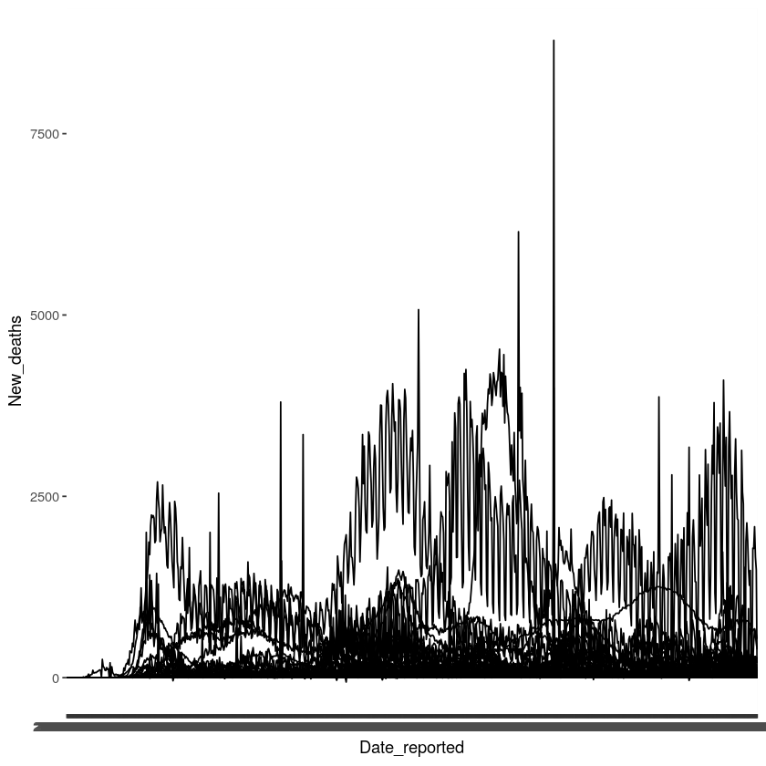

```r
ggplot(data = covall) + geom_line(mapping = aes(x = Date_reported, y = New_deaths, group = Country))
```

```r
length(unique(covall$Country))
```

207

```r
covbeaft <- covall %>% filter((Date_reported >= "2020-09-01") & (Date_reported <= "2021-09-01"))
```

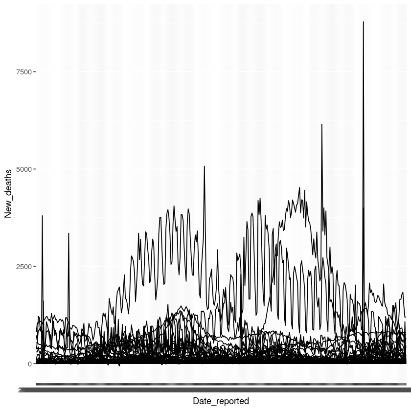

```r
ggplot(data = covbeaft) + geom_line(mapping = aes(x = Date_reported, y = New_deaths, group = Country))
```

```r
eurocov <- covbeaft %>% filter(WHO_region == "EURO")
```

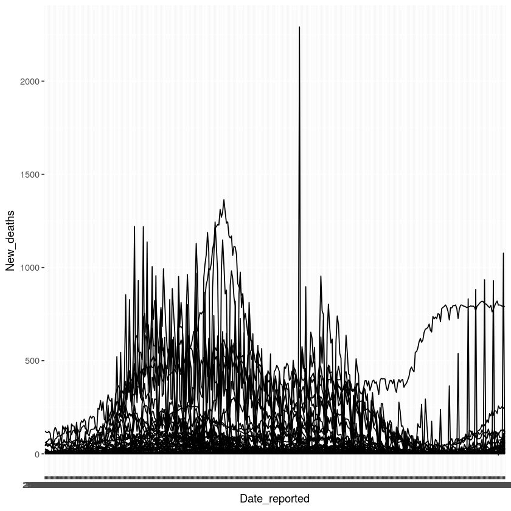

```r
ggplot(data = eurocov) + geom_line(mapping = aes(x = Date_reported, y = New_deaths, group = Country))
```

```r
model <- step(glm(Cumulative_deaths~1, family = gaussian, data = covbeaft),
              scope = ~as.factor(Country)*as.factor(WHO_region)*New_deaths*TOTAL_VACCINATIONS_PER100*PERSONS_VACCINATED_1PLUS_DOSE_PER100*PERSONS_FULLY_VACCINATED_PER100*as.factor(FIRST_VACCINE_DATE)*X2020,
              direction = "forward",
              trace = 1)
```

```
Start:  AIC=1853447
Cumulative_deaths ~ 1
```

```
                                        Df   Deviance     AIC
+ as.factor(Country)                   204 2.9650e+13 1715768
+ as.factor(FIRST_VACCINE_DATE)         96 8.4869e+13 1794456
+ New_deaths                             1 1.0278e+14 1808630
+ X2020                                  1 1.6148e+14 1842530
+ as.factor(WHO_region)                  5 1.7710e+14 1849465
+ PERSONS_VACCINATED_1PLUS_DOSE_PER100   1 1.8198e+14 1851496
+ TOTAL_VACCINATIONS_PER100              1 1.8302e+14 1851926
+ PERSONS_FULLY_VACCINATED_PER100        1 1.8311e+14 1851961
<none>                                     1.8677e+14 1853447

Step:  AIC=1714382
Cumulative_deaths ~ as.factor(Country)
```

```
                                Df  Deviance     AIC
+ New_deaths                     1 2.943e+13 1713823
<none>                             2.965e+13 1714382
+ as.factor(FIRST_VACCINE_DATE)  1 2.965e+13 1714384

Step:  AIC=1713818
Cumulative_deaths ~ as.factor(Country) + New_deaths
```

```
                                 Df   Deviance     AIC
+ as.factor(Country):New_deaths 189 2.6638e+13 1706718
<none>                              2.9430e+13 1713818
+ as.factor(FIRST_VACCINE_DATE)   1 2.9430e+13 1713820

Step:  AIC=1706649
Cumulative_deaths ~ as.factor(Country) + New_deaths + as.factor(Country):New_deaths
```

```
                                Df   Deviance     AIC
<none>                             2.6638e+13 1706649
+ as.factor(FIRST_VACCINE_DATE)  1 2.6638e+13 1706651
```

```r
#summary(model)
```

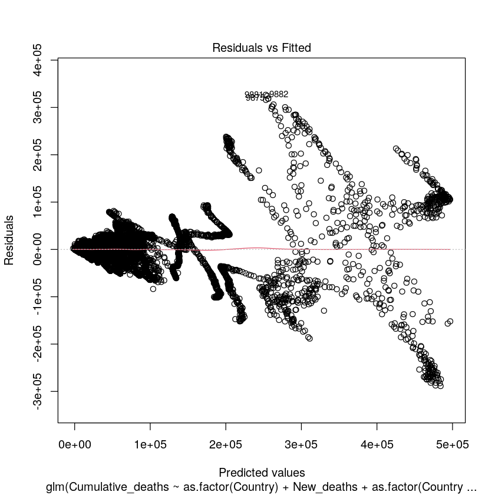

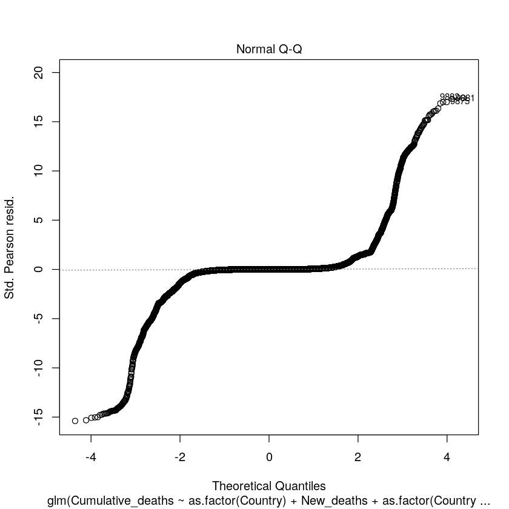

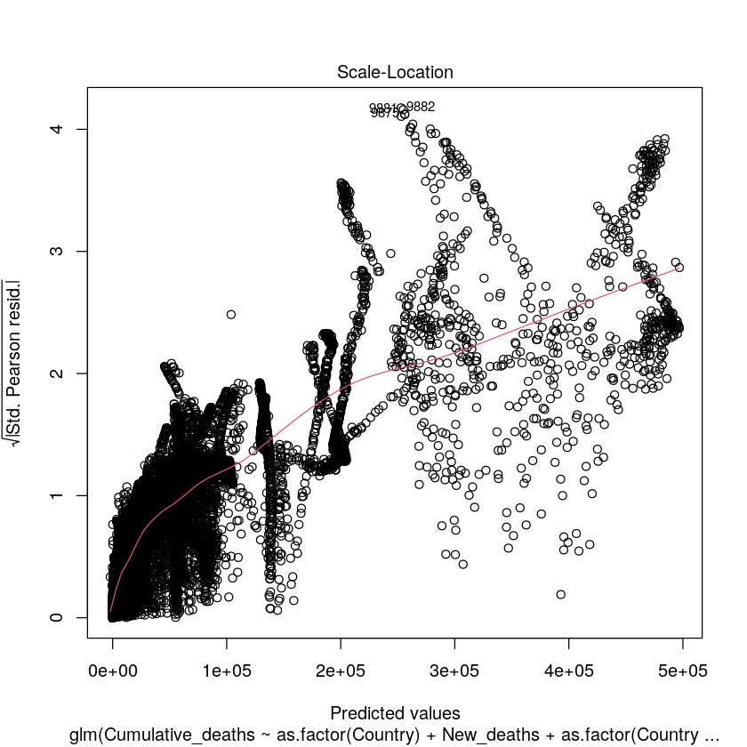

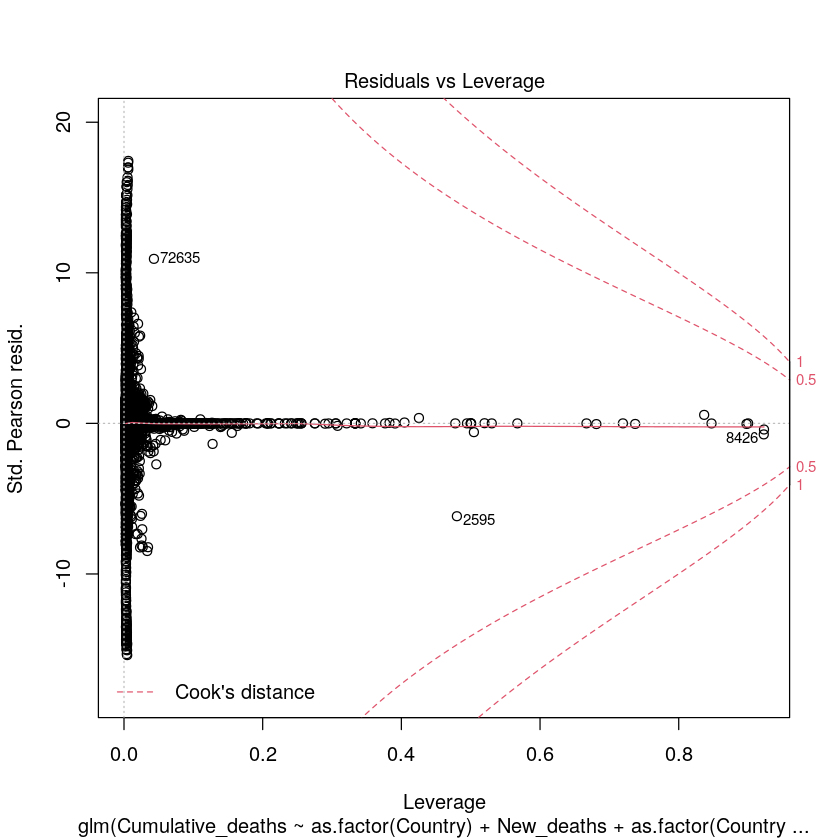

```r
plot(model)
```